# My Test RNA-seq Analysis for GSE236155

B293443

24/03/2025

## RNA-seq pipeline

-“mytable_feaures” - The alignment and annotation (feature counting) of the alignment -You have QC data from FastQC and MultiQC- this can be saved for reference, but you do not need to bring this data into the R pipeline. If you really want you may refer to it from within R if there is a particular feature that you’d like to track through the analysis, but this is quite an unusual situation. -The FastQC results from this example study were OK so I have not looked at these further. =I assume you are in the folder with the annotation results table “mytable_feaures”. -In this example, I load the “mytable_feaures” data for the example study I have been using -I also make a small targets file in R, using some information obtained from GEO - I cut out some of the analysis from the ‘advanced pipeline’ that was not generally relevant. -Since the paper from my study presented a volcano plot with some candidates, I have created my own plot and labelled with their candidate genes to see how the analysis outcomes compare. -I’ve also performed statistical analysis. Actually, there is a slight issue with the version of DESeq2 currently running, and I so some features are not available- see the comments in the text where the model is created.

-Some of the figures and tables do not easily fit in a window and in these cases I’ve output versions that can then be reformatted if required.

-To be ready to run your own version of the analysis you need to have gone though the MultiQC analysis. If you think your data needs trimming then please email. Otherwise, if you are happy with the QC data then put a link in the directory that contains your files (that begins GSE). This link command is ln -s fastq fastq_tr

-What happens then is that the aligner and annotation scripts find this file and complete alignment and annotation for you. -You will be emailed when this is done for you GSE data set.

-Note you should make regular backups of your data. Do not try to copy the FASTQ or BAM files- they are very large. Instead make a backup of the “mytable_feaures” file, QC results and any annotation you create. Save your script (R Markdown) as well and with those file you can re-run the analysis just from the alignment, any annotation data and the R script.

Good luck!

Simon

## Analysis of RNA-seq data using R

```r
#Load the required libraries & load the files for the tutorial
library(Rsubread)
library(edgeR)
```

```r
library(limma)
library(gplots)
library(DESeq2)
library(affy)
library(QuasR)
library(pheatmap)
library(EnhancedVolcano)
getwd()
```

```
## [1] "/localdisk/home/s2850039/FGT/ICA"
```

```r
load(file = "GSE236155/mytable_feaures")
#We now have files for the tutorial and also data loaded into the workspace- use ls() and dir() to view this data
ls()
```

```
## [1] "mytable_feaures"
```

```r
dir()
```

```
##  [1] "B293443_GSE236155.Rmd"  "GSE236155"              "gsea_script.R"
##  [4] "heatmap_candidates.png" "mouse_H_v5p2.rdata"     "paper_genes.csv"
##  [7] "result_sex.csv"         "result_treatment.csv"   "resultAnnot.RData"
## [10] "volcano_test.png"
```

Once we have loaded the data we are ready to run some further analysis.

```r
#Some further processing to access count data and column names.
table_rnaseq<-(mytable_feaures)$counts
colnames_rnaseq <-colnames(table_rnaseq)

#Here I want to generate an 'adf data frame' for the annotation.
#This can be loaded from file but here I generate in  code for a change...
adf <-data.frame(Colnames =colnames_rnaseq)
library(stringr)
locc <- str_locate_all(pattern="Aligned.sortedByCoord.out.bam",adf$Colnames)
adf$ShortGEOName <-substr(adf$Colnames,1,locc[[1]][,"start"]-1)

#From the GEO page for this study- https://www.ncbi.nlm.nih.gov/geo/query/acc.cgi?acc=GSE236155
#GSM7518952 mouse_NC_1
#GSM7518953 mouse_NC_2
#GSM7518954 mouse_NC_3
#GSM7518955 mouse_OE_1
#GSM7518956 mouse_OE_2
#GSM7518957 mouse_OE_3

#My samples are in the same order as the annotaion so I can just create some short names and add to annotation
adf$ShortNames <-c("mouse_NC_1","mouse_NC_2","mouse_NC_3","mouse_OE_1","mouse_OE_2","mouse_OE_3")

#while I am doing this I will create a factor for the treatment
split_names <-str_split(adf$ShortNames, pattern="_")
treatment <-c()
for(i in 1:length(split_names)){
  treatment <-c(treatment,split_names[[i]][2])
}
adf$Treatment <- treatment

#Add some colours as well
#See https://stackoverflow.com/questions/42288075/how-to-autogenerate-color-vector-from-a-numeric-vector
z <- factor(adf$Treatment)
adf$Colours <-rainbow(length(levels(z)))[z]


#make sure the colnames of the study match the rownames of the annotation...
rownames(adf) <-adf$Colnames
if(identical(colnames_rnaseq,rownames(adf))==FALSE){
  print("Names do not match")
}else{
  print("Names match.. OK to proceed")
}
```

```
## [1] "Names match.. OK to proceed"
```

```r
#OK switch to shortnames to help with the figures
#We can only swap this way because column order to consistent with adf
rownames(adf) <-adf$ShortNames
colnames(table_rnaseq) <-adf$ShortNames

colnames_rnaseq <-colnames(table_rnaseq)
```

## Loading the Data into DESeq

DESeq2 will used for the statistical analysis and the normalisation of the data.

```r
#Create object for DESeq
#NOTE the design for differential analysis is fed into this object
dds_rnaseq <- DESeqDataSetFromMatrix(countData = table_rnaseq,colData = adf,design = ~ Treatment)
#check the object dimensions
dim(dds_rnaseq)
```

```
## [1] 78298     6
```

```r
head(rownames(dds_rnaseq))
```

```
## [1] "ENSMUSG00000104478" "ENSMUSG00000104385" "ENSMUSG00000101231"
## [4] "ENSMUSG00000102135" "ENSMUSG00000103282" "ENSMUSG00000101097"
```

```r
colnames(dds_rnaseq)
```

```
## [1] "mouse_NC_1" "mouse_NC_2" "mouse_NC_3" "mouse_OE_1" "mouse_OE_2"
## [6] "mouse_OE_3"
```

```r
#check the object type
class(dds_rnaseq)
```

```
## [1] "DESeqDataSet"
## attr(,"package")
## [1] "DESeq2"
```

```r
typeof(dds_rnaseq)
```

```
## [1] "S4"
```

```r
#check what this object contains
slotNames(dds_rnaseq)
```

```
## [1] "design"             "dispersionFunction" "rowRanges"
## [4] "colData"            "assays"             "NAMES"
## [7] "elementMetadata"    "metadata"
```

```r
colnames(colData(dds_rnaseq))
```

```
## [1] "Colnames"     "ShortGEOName" "ShortNames"   "Treatment"    "Colours"
```

```r
colnames(assay(dds_rnaseq))
```

```
## [1] "mouse_NC_1" "mouse_NC_2" "mouse_NC_3" "mouse_OE_1" "mouse_OE_2"
## [6] "mouse_OE_3"
```

Quality Filtering Genes Apply filters to remove genes that do not pass quality filters.

```r
#first filter based upon counts
keep <- rowSums(counts(dds_rnaseq)) > 1
dds_rnaseq <- dds_rnaseq[keep,]
nrow(dds_rnaseq)
```

```
## [1] 26978
```

## Normalisation of Data

```r
#size factor estimation for normalisation- these are used to scale by library size when data is exported.
dds_rnaseq <- estimateSizeFactors(dds_rnaseq)
sizeFactors(dds_rnaseq)
```

```
## mouse_NC_1 mouse_NC_2 mouse_NC_3 mouse_OE_1 mouse_OE_2 mouse_OE_3
##  1.1776267  1.0428440  1.1006424  0.7956441  0.9066375  1.1092766
```

## DESeq2 also provides methods that outputs data with various normalisations.

Here we generate multiple different normalisations and compare between then- but for the rest of the tutorial we use rlog normalisation! Note that the normalised data is not used for differential expression analysis- just for data visualisation.

```r
#Normalised log counts
counts_rnaseq <-log2(counts(dds_rnaseq, normalized=TRUE) +1)
#fpm is similar to cpm and discussed here https://rdrr.io/bioc/DESeq2/man/fpm.html.  Here the data is log transformed
fpm_rnaseq <-log(fpm(dds_rnaseq) +1)#this is also normalised by the sizeFactors
#rlog and vsd are discussed here https://genomebiology.biomedcentral.com/articles/10.1186/s13059-014-0550-8
vsd_rnaseq <- vst(dds_rnaseq, blind = T)
head(vsd_rnaseq, 3)
```

```
## class: DESeqTransform
## dim: 3 6
## metadata(1): version
## assays(1): ''
## rownames(3): ENSMUSG00000102135 ENSMUSG00000100764 ENSMUSG00000100635
## rowData names(4): baseMean baseVar allZero dispFit
## colnames(6): mouse_NC_1 mouse_NC_2 ... mouse_OE_2 mouse_OE_3
## colData names(6): Colnames ShortGEOName ... Colours sizeFactor
```

```r
rld_rnaseq <- rlog(dds_rnaseq, blind = T)
head(rld_rnaseq, 3)
```

```
## class: DESeqTransform
## dim: 3 6
## metadata(1): version
## assays(1): ''
## rownames(3): ENSMUSG00000102135 ENSMUSG00000100764 ENSMUSG00000100635
## rowData names(7): baseMean baseVar ... dispFit rlogIntercept
## colnames(6): mouse_NC_1 mouse_NC_2 ... mouse_OE_2 mouse_OE_3
## colData names(6): Colnames ShortGEOName ... Colours sizeFactor
```

We will use rlog for the rest of this tutorial, but here we compare the different normalised data

##Plots with Normalised Data.

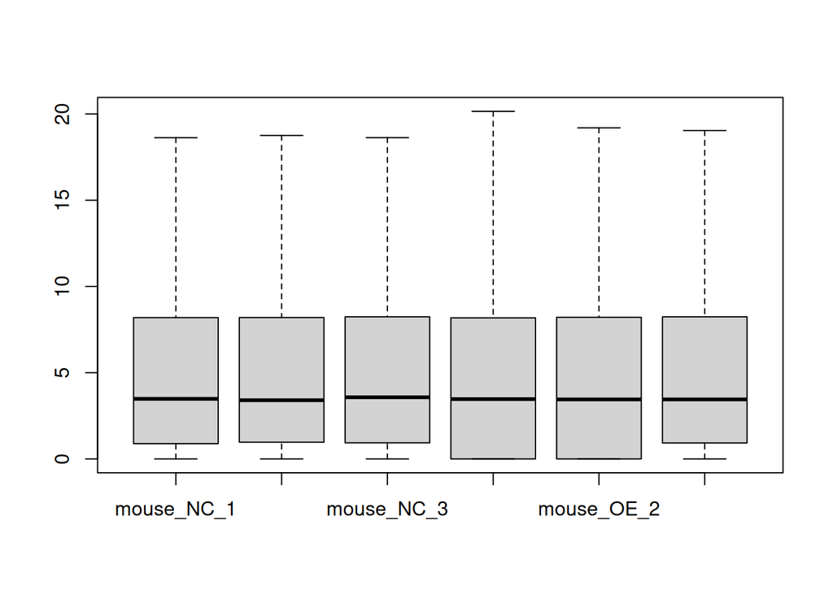

```r
#Boxplots need some labels..
boxplot(counts_rnaseq)
```

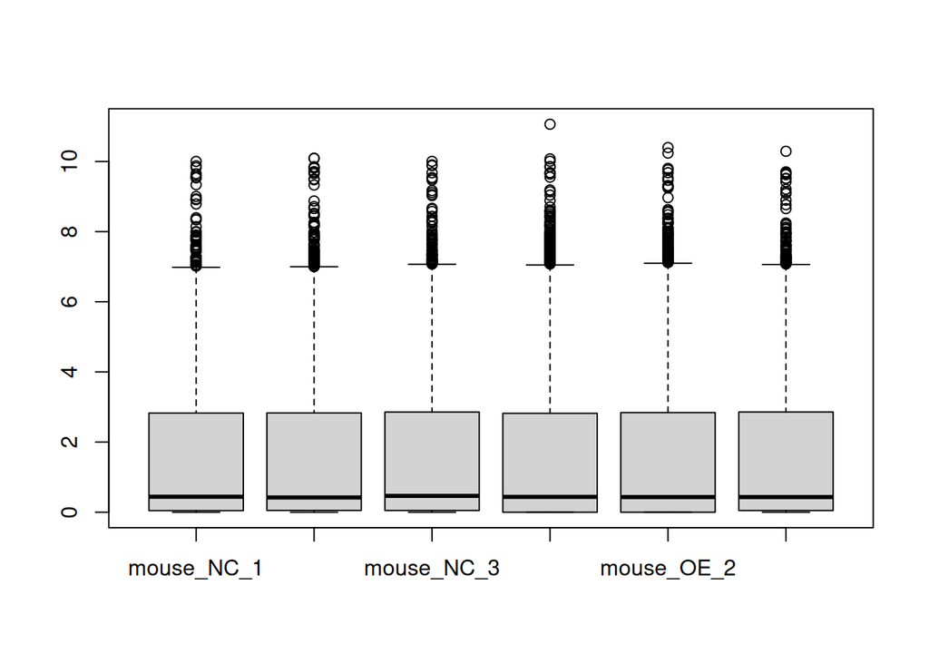

```r
boxplot(fpm_rnaseq)
```

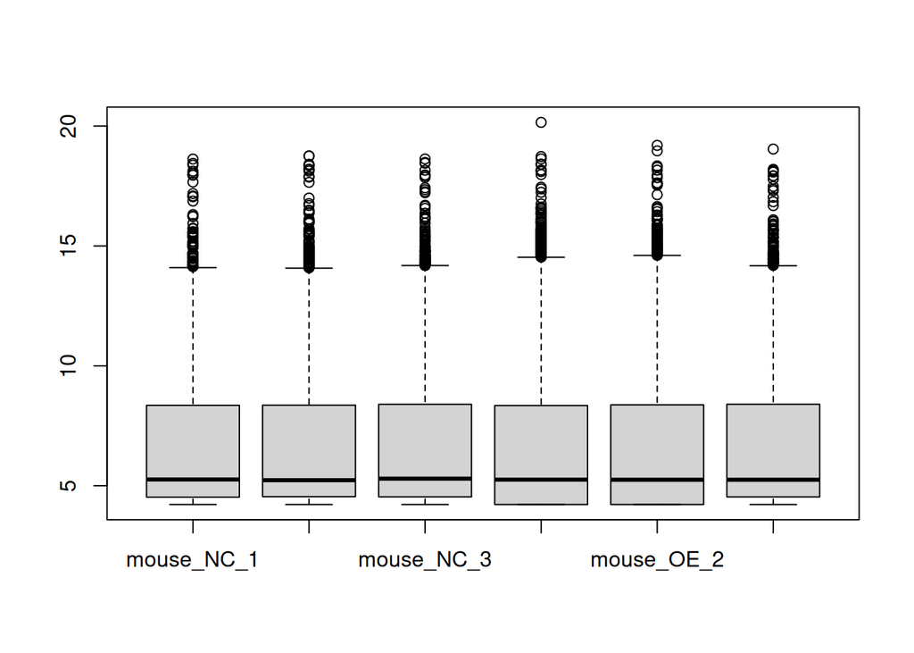

```r
boxplot(assay(vsd_rnaseq))#etc
```

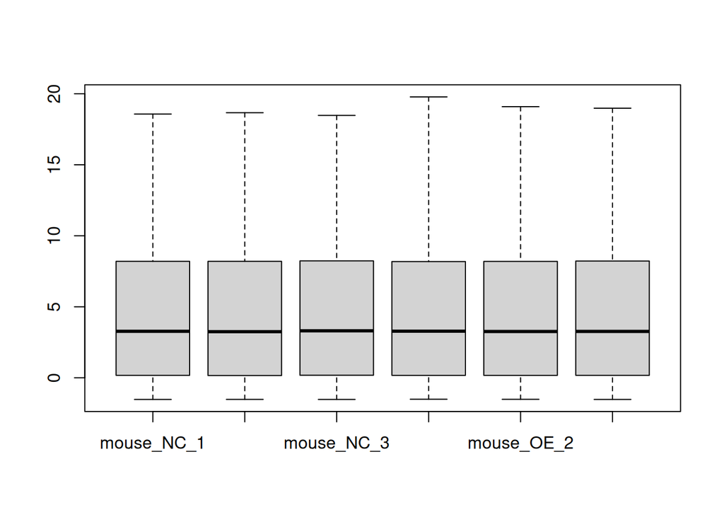

```r
boxplot(assay(rld_rnaseq))#etc
```

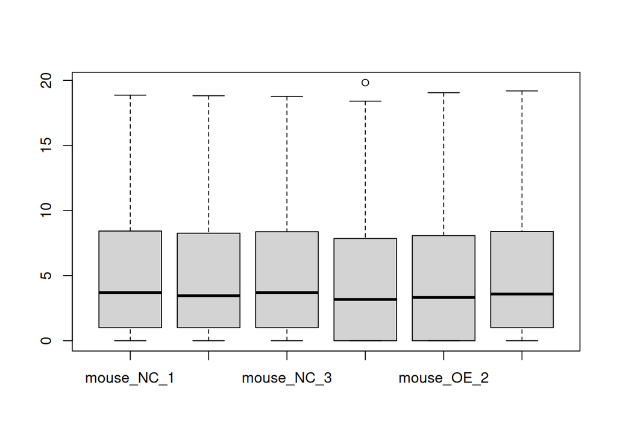

```r
#but suppose we look at non-normalised
na.rm=T
counts_un <-counts(dds_rnaseq, normalized=FALSE)+1

boxplot(log2(counts_un))
```

```r
counts_un_rlog<-rlog(counts_un)
```

```r
#We can make an mva.pairs plot for any of these data
#mva.pairs(counts_un_rlog,na.rm=TRUE)
```

Exploratory Data Plots PCA plots similar to those we use for microarrays.

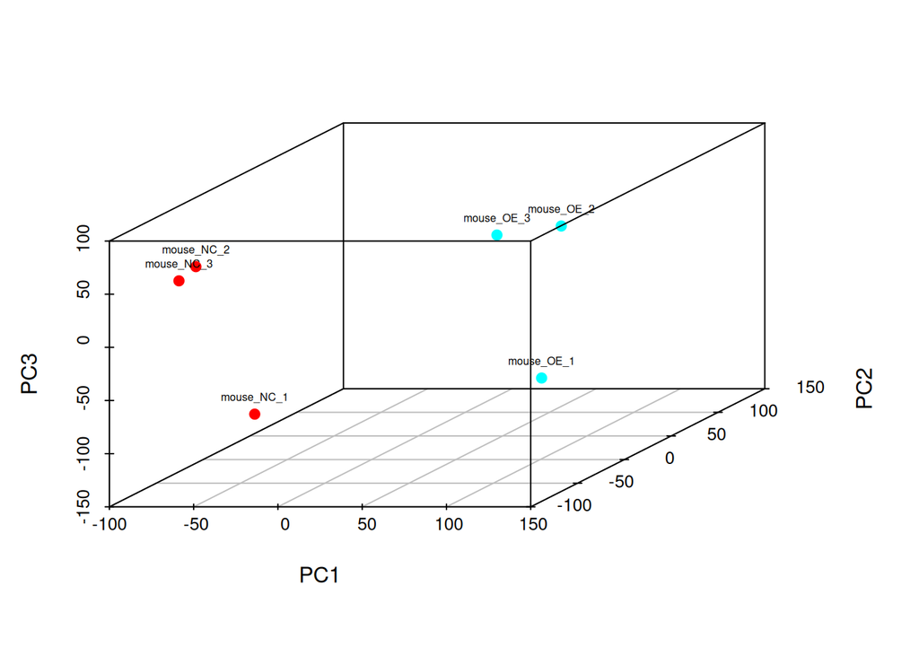

```r
#we can run a PCA plot here...
library(scatterplot3d)
library(ggplot2)
# Perform PCA
pca <- prcomp(t(na.omit(assay(rld_rnaseq))), scale=T)
# Plot the PCA results
s3d<-scatterplot3d(pca$x[,1:3], pch=19, color=adf$Colours)
s3d.coords <- s3d$xyz.convert(pca$x[,1:3])
text(s3d.coords$x, s3d.coords$y, labels = colnames(rld_rnaseq),pos = 3,offset = 0.5,cex=0.5)
```

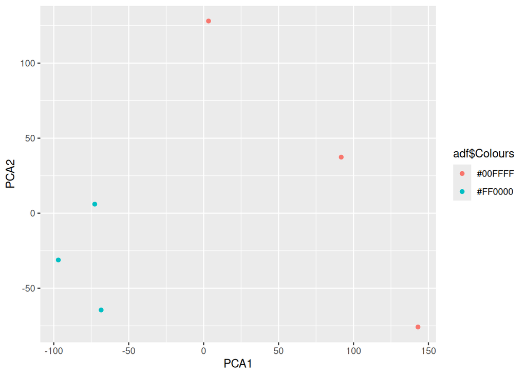

```r
#or a quick plot in 2d
qplot(pca$x[,1],pca$x[,2],xlab="PCA1", ylab="PCA2",color=adf$Colours)
```

```r
#We can also output a distance matrix…
sampleDists <- dist(t(assay(rld_rnaseq)))
sampleDists
```

```
##            mouse_NC_1 mouse_NC_2 mouse_NC_3 mouse_OE_1 mouse_OE_2
## mouse_NC_2   49.23755
## mouse_NC_3   53.28377   38.57856
## mouse_OE_1   89.98427   96.58433  103.97108
## mouse_OE_2   80.11415   88.80991   96.26863   47.00624
## mouse_OE_3   65.28357   73.43382   74.93606   70.93949   55.53276
```

## Generate further heatmaps with the data

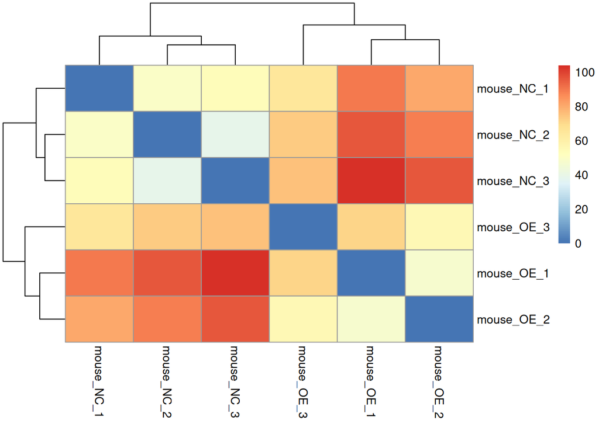

```r
library("pheatmap")
library("RColorBrewer")
sampleDistMatrix <- as.matrix(sampleDists)
pheatmap(sampleDistMatrix)
```

```r
#easier PCA plot
ress <-plotPCA(rld_rnaseq, intgroup = c("Treatment"))
```

```
## using ntop=500 top features by variance
```

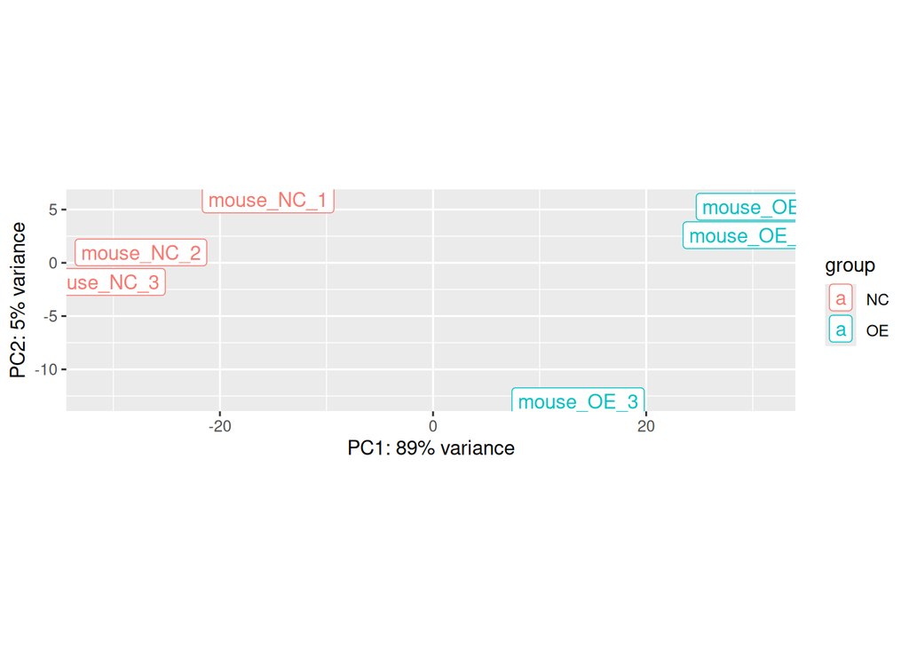

```r
ress <- ress + geom_label(aes(label = name))
plot(ress)
```

## Differential Gene Expression

Simplified stats

```r
dds_rnaseq <- DESeq(dds_rnaseq)
```

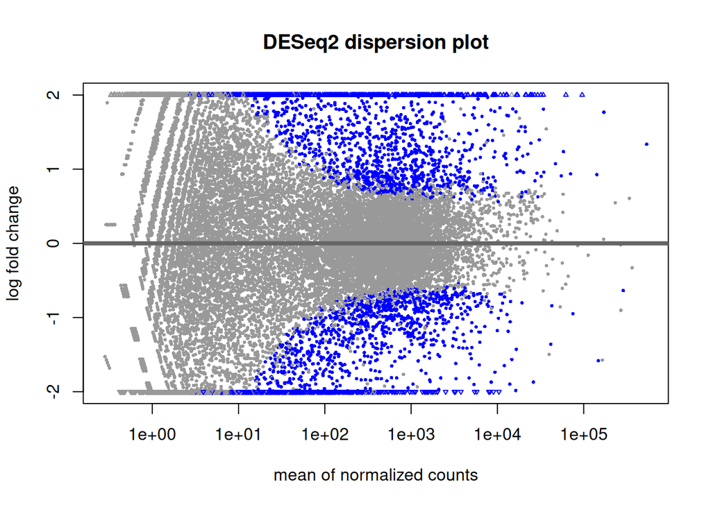

```r
#We should apply this here https://support.bioconductor.org/p/77461/#107693
#But there is a bug in this version of DESeq2!!
#dds_rnaseq <- lfcShrink(dds_rnaseq, coef=2)




#This is how you specify a contrast...
#note: results(dds, contrast=c("condition","A","B")): genes with logFC > 0 overexpressed in A https://support.bioconductor.org/p/134510/
result_treatment <-results(dds_rnaseq,contrast=c("Treatment","OE","NC"))






#make a nice plot of differential expression
plotMA(result_treatment, main="DESeq2 dispersion plot", ylim=c(-2,2))
```

```r
table(result_treatment$padj < 0.01)
```

```
##
## FALSE  TRUE
## 15839  1723
```

```r
table(result_treatment$padj < 0.05)
```

```
##
## FALSE  TRUE
## 14973  2589
```

```r
result_treatment_selected <- subset(result_treatment, padj < 0.05)
result_treatment <-result_treatment[order(abs(result_treatment$stat),decreasing = TRUE), ]
head(result_treatment)
```

```
## log2 fold change (MLE): Treatment OE vs NC
## Wald test p-value: Treatment OE vs NC
## DataFrame with 6 rows and 6 columns
##                     baseMean log2FoldChange     lfcSE      stat       pvalue
##                    <numeric>      <numeric> <numeric> <numeric>    <numeric>
## ENSMUSG00000041324  8849.261        7.60894  0.333730   22.7997 4.61638e-115
## ENSMUSG00000026822  8989.296        7.94156  0.369996   21.4639 3.38905e-102
## ENSMUSG00000037664   965.429       -5.79616  0.334634  -17.3209  3.27293e-67
## ENSMUSG00000033213  7217.410        5.38976  0.326271   16.5193  2.66546e-61
## ENSMUSG00000039196  1377.375        5.92825  0.368184   16.1013  2.49721e-58
## ENSMUSG00000031722 10838.075        5.31095  0.331046   16.0429  6.40407e-58
##                            padj
##                       <numeric>
## ENSMUSG00000041324 8.10729e-111
## ENSMUSG00000026822  2.97593e-98
## ENSMUSG00000037664  1.91597e-63
## ENSMUSG00000033213  1.17027e-57
## ENSMUSG00000039196  8.77119e-55
## ENSMUSG00000031722  1.87447e-54
```

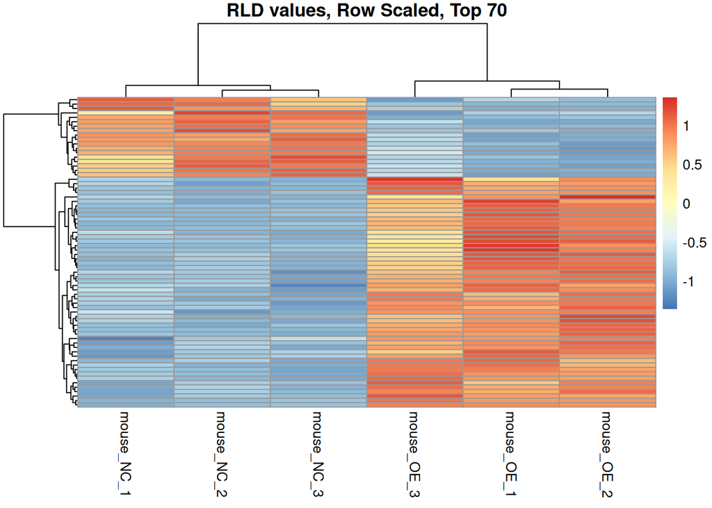

```r
top70 <-rownames(result_treatment)[1:70]
#make a heatmap for the top 70
pheatmap(assay(rld_rnaseq)[top70,],scale="row",show_rownames=F,main="RLD values, Row Scaled, Top 70")
```

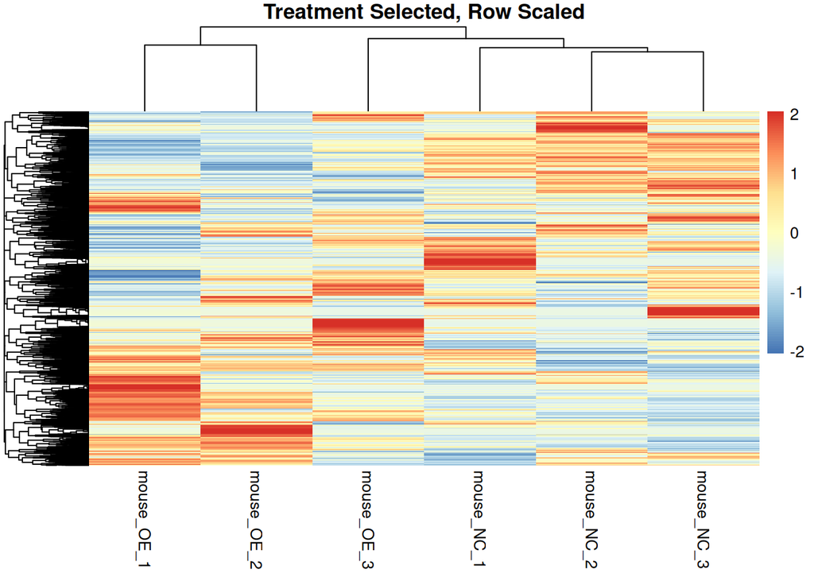

```r
#all
pheatmap(assay(rld_rnaseq)[rownames(result_treatment),],scale="row",show_rownames=F,main="Treatment Selected, Row Scaled")
```

## Build Gene Annotation. A serialised is generated in case Ensembl is unavailable

```r
#Download Ensembl annotation using BiomaRt and rename the samples
library(biomaRt)
if(file.exists("resultAnnot.RData")){

  load("resultAnnot.RData")
  print("Loaded existing Ensembl annotation...")
}else{

  #UK ensembl is being updated  we use a USA mirror, "useast.ensembl.org"
  ensembl_host <-"https://www.ensembl.org"
  head(biomaRt::listMarts(host = ensembl_host), 15)
  head(biomaRt::listAttributes(biomaRt::useDataset(dataset = "mmusculus_gene_ensembl",mart = useMart("ENSEMBL_MART_ENSEMBL",host = ensembl_host))), 40)
  mart <- biomaRt::useDataset(dataset = "mmusculus_gene_ensembl",mart    = useMart("ENSEMBL_MART_ENSEMBL",host    = ensembl_host))
  resultAnnot <- biomaRt::getBM(values=rownames(dds_rnaseq),attributes =     c("ensembl_gene_id","external_gene_name","chromosome_name","start_position","end_position","description","strand"),filters="ensembl_gene_id",mart=mart)
  save(resultAnnot,file="resultAnnot.RData")
}
```

```
## [1] "Loaded existing Ensembl annotation..."
```

Merge Annotation with Input Data

```r
#merge with input data
names <- resultAnnot[,1]
resultAnnot <- as.data.frame(resultAnnot)
resultAnnot <- resultAnnot[!duplicated(resultAnnot$ensembl_gene_id), ]
idx<-match(rownames(dds_rnaseq),resultAnnot$ensembl_gene_id)
resultAnnot <- resultAnnot[idx, ]

unmatched_ids <- rownames(dds_rnaseq)[is.na(resultAnnot$ensembl_gene_id)]
resultAnnot$ensembl_gene_id[is.na(resultAnnot$ensembl_gene_id)] <- unmatched_ids

all(resultAnnot$ensembl_gene_id == rownames(dds_rnaseq))
```

```
## [1] TRUE
```

```r
rownames(resultAnnot) <- resultAnnot$ensembl_gene_id
all(rownames(dds_rnaseq) == rownames(resultAnnot))
```

```
## [1] TRUE
```

```r
grr<-resultAnnot[match(rownames(dds_rnaseq), resultAnnot$ensembl_gene_id),]
all(rownames(dds_rnaseq) == rownames(grr))
```

```
## [1] TRUE
```

```r
resultAnnot <-grr
all(rownames(dds_rnaseq) == rownames(resultAnnot))
```

```
## [1] TRUE
```

```r
#make the nice names
names <- names[idx]
resultAnnot$ensembl_gene_id <- names
nice_names<-ifelse(resultAnnot$external_gene_name == resultAnnot$ensembl_gene_id,
                   resultAnnot$ensembl_gene_id,
                   paste(resultAnnot$ensembl_gene_id,resultAnnot$external_gene_name, sep = '_'))
resultAnnot$nice_names <-nice_names
head(resultAnnot)
```

```
##                       ensembl_gene_id external_gene_name chromosome_name
## ENSMUSG00000102135 ENSMUSG00000102135            Gm37108               1
## ENSMUSG00000100764 ENSMUSG00000100764            Gm29155               1
## ENSMUSG00000100635 ENSMUSG00000100635            Gm29157               1
## ENSMUSG00000100480 ENSMUSG00000100480            Gm29156               1
## ENSMUSG00000100025 ENSMUSG00000100025             Gm8141               1
## ENSMUSG00000051285 ENSMUSG00000051285             Pcmtd1               1
##                    start_position end_position
## ENSMUSG00000102135        6986783      6993812
## ENSMUSG00000100764       43781121     43783055
## ENSMUSG00000100635       43782075     43782686
## ENSMUSG00000100480       43784944     43785442
## ENSMUSG00000100025      109760754    109762476
## ENSMUSG00000051285        7159144      7243852
##                                                                                                                         description
## ENSMUSG00000102135                                                        predicted gene, 37108 [Source:MGI Symbol;Acc:MGI:5610336]
## ENSMUSG00000100764                                                         predicted gene 29155 [Source:MGI Symbol;Acc:MGI:5579861]
## ENSMUSG00000100635                                                         predicted gene 29157 [Source:MGI Symbol;Acc:MGI:5579863]
## ENSMUSG00000100480                                                         predicted gene 29156 [Source:MGI Symbol;Acc:MGI:5579862]
## ENSMUSG00000100025                                                          predicted gene 8141 [Source:MGI Symbol;Acc:MGI:3647473]
## ENSMUSG00000051285 protein-L-isoaspartate (D-aspartate) O-methyltransferase domain containing 1 [Source:MGI Symbol;Acc:MGI:2441773]
##                    strand                 nice_names
## ENSMUSG00000102135      1 ENSMUSG00000102135_Gm37108
## ENSMUSG00000100764     -1 ENSMUSG00000100764_Gm29155
## ENSMUSG00000100635      1 ENSMUSG00000100635_Gm29157
## ENSMUSG00000100480     -1 ENSMUSG00000100480_Gm29156
## ENSMUSG00000100025      1  ENSMUSG00000100025_Gm8141
## ENSMUSG00000051285      1  ENSMUSG00000051285_Pcmtd1
```

```r
all(rownames(dds_rnaseq) == rownames(resultAnnot))
```

```
## [1] TRUE
```

[figure not shown]

```r
#check names
rld_rnaseq <- rlog(dds_rnaseq, blind = TRUE)#
idx2 <-match(rownames(result_treatment)[1:50],rownames(dds_rnaseq))
plotme <-(rld_rnaseq)[rownames(result_treatment)[1:50],]

rownames(plotme)<-resultAnnot$nice_names[idx2]
#make heatmap with candidate genes
png(filename="heatmap_candidates.png",width=800, height=1000)
pheatmap(assay(plotme),scale="row",fontsize_row = 10,cellheight =12, cellwidth =12,treeheight_row = 40, treeheight_col = 40)
```

```r
dev.off()
```

```r
pheatmap(assay(plotme),scale="row",fontsize_row = 10,cellheight =12, cellwidth =12,treeheight_row = 80, treeheight_col = 100)
```

## Final Results Table

Since we have annotation that matches gene names to candidates we can also annotate the results table from differential expression

```r
#this has the results ordered

#before
head(result_treatment,50)
```

```
## log2 fold change (MLE): Treatment OE vs NC
## Wald test p-value: Treatment OE vs NC
## DataFrame with 50 rows and 6 columns
##                     baseMean log2FoldChange     lfcSE      stat       pvalue
##                    <numeric>      <numeric> <numeric> <numeric>    <numeric>
## ENSMUSG00000041324  8849.261        7.60894  0.333730   22.7997 4.61638e-115
## ENSMUSG00000026822  8989.296        7.94156  0.369996   21.4639 3.38905e-102
## ENSMUSG00000037664   965.429       -5.79616  0.334634  -17.3209  3.27293e-67
## ENSMUSG00000033213  7217.410        5.38976  0.326271   16.5193  2.66546e-61
## ENSMUSG00000039196  1377.375        5.92825  0.368184   16.1013  2.49721e-58
## ...                      ...            ...       ...       ...          ...
## ENSMUSG00000021831  5855.818        2.78184  0.265010   10.4971  8.90894e-26
## ENSMUSG00000034248  2118.806        3.44991  0.329143   10.4815  1.05083e-25
## ENSMUSG00000056145   317.782        3.66476  0.350071   10.4686  1.20382e-25
## ENSMUSG00000135102  6269.870        3.91671  0.377353   10.3794  3.07560e-25
## ENSMUSG00000051439 31880.192        3.86343  0.372444   10.3732  3.28379e-25
##                            padj
##                       <numeric>
## ENSMUSG00000041324 8.10729e-111
## ENSMUSG00000026822  2.97593e-98
## ENSMUSG00000037664  1.91597e-63
## ENSMUSG00000033213  1.17027e-57
## ENSMUSG00000039196  8.77119e-55
## ...                         ...
## ENSMUSG00000021831  3.40128e-23
## ENSMUSG00000034248  3.92654e-23
## ENSMUSG00000056145  4.40448e-23
## ENSMUSG00000135102  1.10232e-22
## ENSMUSG00000051439  1.15340e-22
```

```r
annot_2 <- resultAnnot
idx3 <- match(rownames(result_treatment), annot_2$ensembl_gene_id)

new_names <- annot_2$nice_names[idx3]
new_names[is.na(new_names)] <- rownames(result_treatment)[is.na(new_names)]

rownames(result_treatment)<-new_names
#after
print(result_treatment[1:50,])
```

```
## log2 fold change (MLE): Treatment OE vs NC
## Wald test p-value: Treatment OE vs NC
## DataFrame with 50 rows and 6 columns
##                              baseMean log2FoldChange     lfcSE      stat
##                             <numeric>      <numeric> <numeric> <numeric>
## ENSMUSG00000041324_Inhba     8849.261        7.60894  0.333730   22.7997
## ENSMUSG00000026822_Lcn2      8989.296        7.94156  0.369996   21.4639
## ENSMUSG00000037664_Cdkn1c     965.429       -5.79616  0.334634  -17.3209
## ENSMUSG00000033213_AA467197  7217.410        5.38976  0.326271   16.5193
## ENSMUSG00000039196_Orm1      1377.375        5.92825  0.368184   16.1013
## ...                               ...            ...       ...       ...
## ENSMUSG00000021831_Ero1a     5855.818        2.78184  0.265010   10.4971
## ENSMUSG00000034248_Slc25a37  2118.806        3.44991  0.329143   10.4815
## ENSMUSG00000056145_AI504432   317.782        3.66476  0.350071   10.4686
## ENSMUSG00000135102_Gm61113   6269.870        3.91671  0.377353   10.3794
## ENSMUSG00000051439_Cd14     31880.192        3.86343  0.372444   10.3732
##                                   pvalue         padj
##                                <numeric>    <numeric>
## ENSMUSG00000041324_Inhba    4.61638e-115 8.10729e-111
## ENSMUSG00000026822_Lcn2     3.38905e-102  2.97593e-98
## ENSMUSG00000037664_Cdkn1c    3.27293e-67  1.91597e-63
## ENSMUSG00000033213_AA467197  2.66546e-61  1.17027e-57
## ENSMUSG00000039196_Orm1      2.49721e-58  8.77119e-55
## ...                                  ...          ...
## ENSMUSG00000021831_Ero1a     8.90894e-26  3.40128e-23
## ENSMUSG00000034248_Slc25a37  1.05083e-25  3.92654e-23
## ENSMUSG00000056145_AI504432  1.20382e-25  4.40448e-23
## ENSMUSG00000135102_Gm61113   3.07560e-25  1.10232e-22
## ENSMUSG00000051439_Cd14      3.28379e-25  1.15340e-22
```

```r
#load into table viewer
#View(as.data.frame(result_treatment[1:50,]))
```

## The source paper showed candidates in a volcano plot- this is to compare

Current row names are not useful here- we need to use genes but then will discard any without known names. This is OK here because we are exploring the annotation -genes without a gene name and so are no use for annotating the data.

We can still keep unannoted genes as candidates!

```r
result_treatment$gene<-annot_2$external_gene_name[idx3]
write.csv(as.data.frame(result_treatment), "result_treatment.csv")
has_annot <- is.na(result_treatment$gene)
has_annot <-!has_annot
result_treatment<-result_treatment[has_annot,]
rownames(result_treatment)<-result_treatment$gene

#Now we have gene names so we can plot the remaining genes in a volcano plot

#there were highlighted as interesting in the paper
paper_genes <-c("Cd36","Abca1","Abcg1","Abcg2","Abcg3","Abca8a","Abca8b","Abca9","Pparg")


#just check they're measured in this annotation
if(sum(paper_genes %in% rownames(result_treatment))==length(paper_genes)){
  print("all genes found in data")
}#you'd just include a subset to label if some genes were missing- here they are all present
```

```
## [1] "all genes found in data"
```

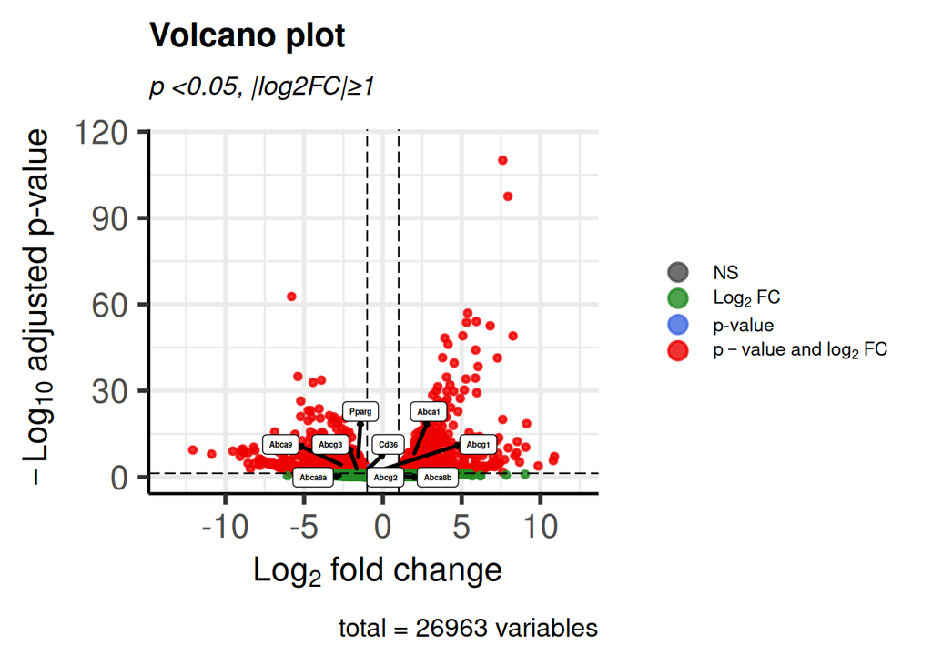

```r
#The paper found...
#for volvano see
#https://bioconductor.org/packages/devel/bioc/vignettes/EnhancedVolcano/inst/doc/EnhancedVolcano.html
volcano_test <-EnhancedVolcano(result_treatment,
    lab = rownames(result_treatment),
    x = 'log2FoldChange',
    y = 'padj',
    selectLab = paper_genes,
    xlab = bquote(~Log[2]~ 'fold change'),
    ylab = bquote(~-Log[10] ~ "adjusted p-value"),
    subtitle = bquote(italic("p <0.05, |log2FC|≥1")),
    pCutoff = 0.05,
    FCcutoff = 1.0,
    max.overlaps = Inf,
    pointSize = 1.0,
    labSize = 1.5,
    labCol = 'black',
    labFace = 'bold',
    boxedLabels = TRUE,
    colAlpha = 4/5,
    legendPosition = 'right',
    legendLabSize = 10,
    legendIconSize = 4.0,
    drawConnectors = TRUE,
    widthConnectors = 1.0,
    colConnectors = 'black')
plot(volcano_test,xlim=800,ylim=800)
```

```r
png("volcano_test.png",width = 800, height = 800)
plot(volcano_test)
dev.off()
```

```r
#and look at the table
#View(as.data.frame(result_treatment[paper_genes,]))

print(as.data.frame(result_treatment[paper_genes,]))
```

```
##            baseMean log2FoldChange     lfcSE      stat       pvalue
## Cd36   14070.487519     -1.0561558 0.3057944 -3.453810 5.527263e-04
## Abca1   5945.738418      1.9462551 0.3117422  6.243155 4.288308e-10
## Abcg1   2584.513683     -0.7088646 0.2511647 -2.822310 4.767911e-03
## Abcg2    176.558947     -0.8099364 0.3641555 -2.224150 2.613837e-02
## Abcg3    111.232661     -1.6213244 0.4623819 -3.506461 4.541073e-04
## Abca8a     6.054722     -2.5801090 1.3098033 -1.969845 4.885618e-02
## Abca8b    35.219817      0.7889809 0.5129537  1.538113 1.240209e-01
## Abca9    103.736616     -2.5270075 0.5535976 -4.564701 5.002065e-06
## Pparg    387.580180     -1.5801852 0.2803139 -5.637199 1.728385e-08
##                padj   gene
## Cd36   6.249824e-03   Cd36
## Abca1  2.502035e-08  Abca1
## Abcg1  3.576687e-02  Abcg1
## Abcg2  1.258339e-01  Abcg2
## Abcg3  5.277983e-03  Abcg3
## Abca8a 1.933413e-01 Abca8a
## Abca8b 3.519237e-01 Abca8b
## Abca9  1.102212e-04  Abca9
## Pparg  7.175861e-07  Pparg
```

```r
write.csv(as.data.frame(result_treatment[paper_genes,]), "paper_genes.csv")
```